# Statistical Analysis of Gender Pay Disparities in University Faculty Salaries

DATA 557 W26 Final Project - Interactive Data Story

Maanya Cola Bharath, Roxanne Dimadi, Ha Tien Nguyen, Hannah Sun, Pavan Suresh, Lay Yang

2026-03-15

# 1. Introduction

Gender pay disparities have been widely documented across many labor markets, including academia. Because salary discrimination based on sex is illegal in the United States, differences in salary between male and female faculty members are often debated. Some argue that disparities may arise from discrimination, while others attribute them to differences in experience, academic field, promotion history, or administrative responsibilities. These factors may also be interrelated, making it challenging to isolate the independent effect of gender on salary disparities.

This project investigates whether gender-based salary disparities exist among faculty at a particular U.S. university. We examine whether systematic differences in salary or promotion outcomes exist between male and female faculty members.

Specifically, we address four questions:

1. Does wage discrimination exist in the starting salaries of faculty members (i.e., salaries in the year hired)?
2. Does wage discrimination exist in granting promotions from Associate Professor to Full Professor?
3. Overall: Is there wage discrimination in salaries at the university?
4. What issues are involved in generalizing our results?

All analyses assesses statistical significance at the a = 0.05 level using two-sided tests.

# 2. Data

The dataset contains salary records for faculty members employed at a single U.S. university between 1976 and 1995. Each observation corresponds to a faculty member in a particular year. The dataset includes 19,788 salary records representing 1,597 unique faculty members.

Key variables include:

- sex - gender of the faculty member (Male or Female)
- salary - monthly salary in dollars
- rank - faculty rank (Assistant, Associate, Full)
- field - academic field category (Arts, Professional, Other)
- yrdeg - year highest degree was attained
- startyr - year faculty member was hired
- year - observation year
- admin - indicator for administrative duties

The derived variable, experience, was created during preprocessing. It is calculated as the difference between the observation year and the year hired.

Observations with invalid values, such as missing rank information, were removed during data cleaning.

# 3. Exploratory Data Analysis

We conduct a preliminary exploratory data analysis (EDA) to examine the structure of the dataset and identify general patterns in salaries across gender, rank, and time.

### Gender Composition of the Dataset

We begin by examining the distribution of observations by gender. The dataset contains substantially more observations for men than for women. Although this imbalance does not invalidate statistical comparisons, it is important to recognize that differences in sample size may affect the variability of estimates and the precision of statistical tests.

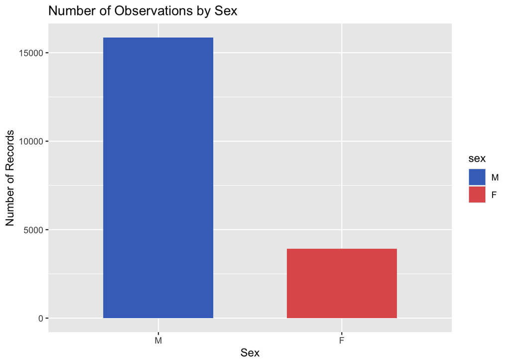

### Salary Trends Over Time by Sex

The time series plot shows that salaries increase steadily between 1976 and 1995 for both groups. Across all years, the average salary for men appears higher than that for women. At first galance, this pattern may suggest the presence of a gender wage gap. However, because academic salaries are strongly structured by rank, differences in the distribution of men and women across ranks could influence these aggregate averages. This possibility motivates a closer examination of salary distributions within each rank.

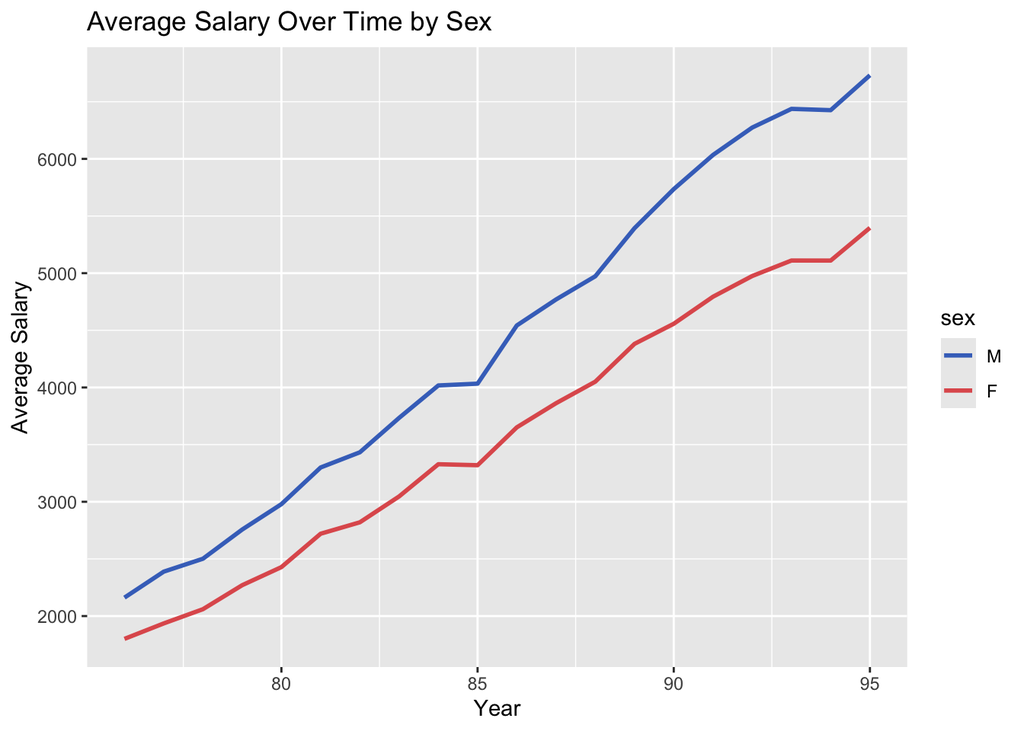

### Salary Distribution by Sex Within Rank

The boxplots show that salaries increase substantially with rank, with Full Professors earning the highest salaries on average, followed by Associate Professors and then Assistant Professors. Within each rank, male and female salary distributions appear broadly similar, with the median female salary slightly higher in both Assistant and Associate groups. These patterns suggest that some observed salary differences may arise from differences in rank composition as well as potential within-rank wage gaps. This suggests an important statistical issue known as Simpson’s paradox, where patterns observed in aggregate data can differ from patterns observed within subgroups. If men are disproportionately represented in higher-paying ranks, the overall average salary for men may appear higher even if salaries are similar within individual ranks.

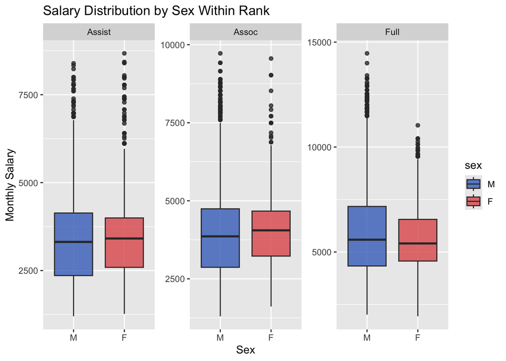

These exploratory plots emphasize the importance of accounting for rank when analyzing gender differences in salaries, which we address explicitly in our Question 2 analysis section.

# 4. Q1: Starting Salary Discrimination

To investigate whether gender discrimination exists in starting salaries, the dataset was filtered to include only the first year of employment for each faculty member (where year = startyr). This resulted in 1,107 starting salary observations. The mean starting salaries were $4,015.55 for men and $3600.32 for women. The mean starting salary for male faculty was approximately $415 higher than that of female faculty. Although the majority of newly hired faculty were Assistant Professors, some individuals were hired directly at the Associate or Full Professor ranks.

### Starting Salary Distribution by Sex

We first examine the distribution of starting salaries separately for male and female faculty members. The histograms indicate that starting salaries for both groups follow a right-skewed distribution. While the overall shapes of the distributions are similar, the distribution for men shows a greater number of observations above $5000.

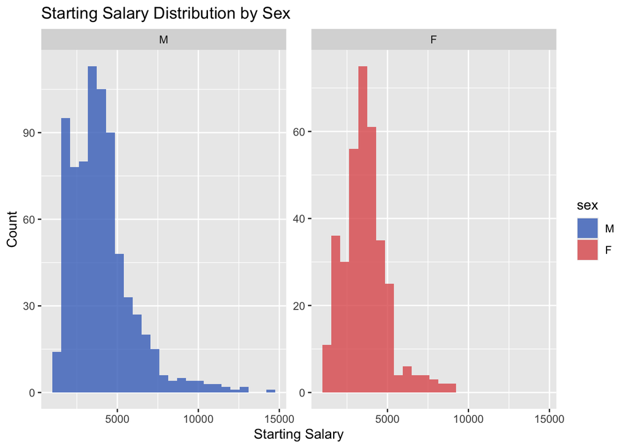

### Starting Salary by Academic Field and Sex

The boxplots show that Professional fields exhibit the highest median starting salaries, followed by Other fields and then Arts fields. This suggests that academic field may play an important role in determining initial compensation. In both the Arts and Professional fields, the median starting salary for women are slightly higher than that for men, while the male median starting salary is slightly higher in the Other field. These patterns indicate that differences in starting salaries may vary across academic fields, highlighting the importance for controlling for field.

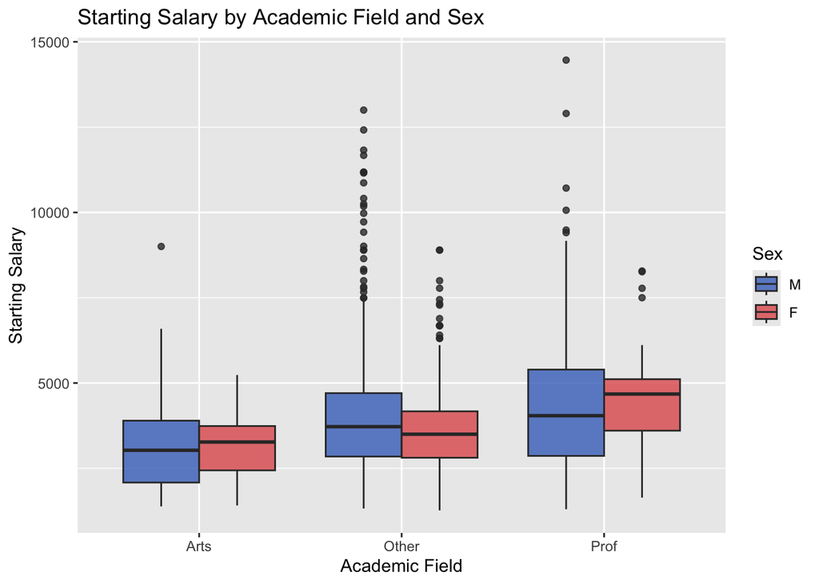

### Starting Salary by Sex, Rank, and Field

When starting salaries are examined jointly by rank and field, the median salary is not consistently higher for one gender across all groups. Notably, within the Professional field, women have higher median starting salaries than men at all three ranks (Assistant, Associate, and Full). In the Arts field and Other field, male median starting salaries are higher at Associate and Full ranks, while female median starting salary is higher at the Assistant rank. Therefore, both academic rank and field should be controlled for in subsequent analyses.

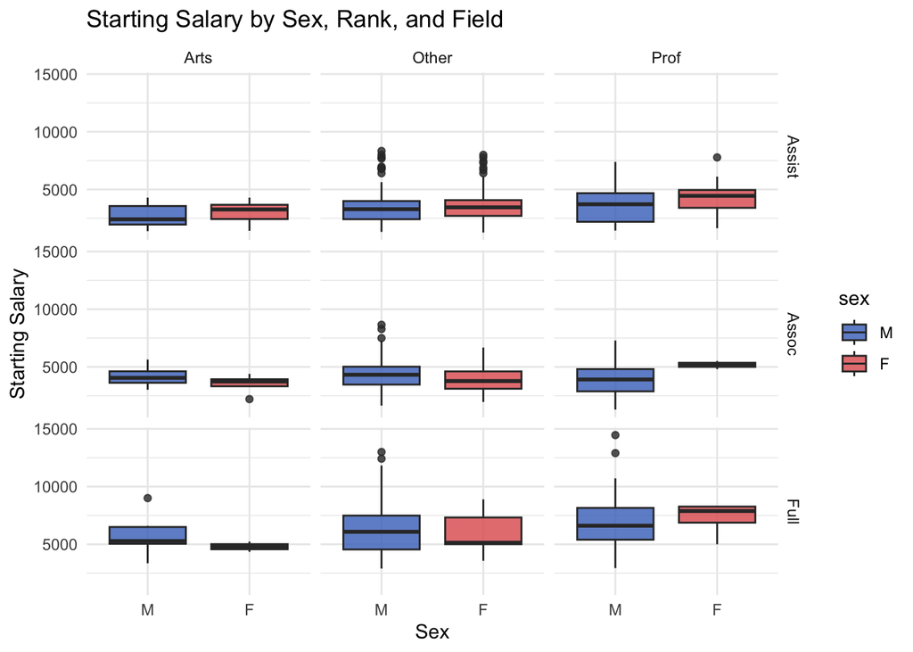

### Statistical Tests

We test the null hypothesis $H_0: \mu_M - \mu_F = 0$ against the two-sided alternative $H_A: \mu_M - \mu_F \neq 0$, where $\mu_M$ and $\mu_F$ denote the population mean starting salaries for male and female faculty, respectively.

We conducted a Welch two-sample t-test to determine whether the difference in means is statistically significant. Since the histograms of starting salary distribution by sex show deviation from normality, we also perform a z-test based on the normal approximation to compare mean starting salaries between men and women. In both tests, we obtain a test statistic of 4.1326 and a p-value less than 0.001. The observed difference in starting salaries between men and women is 4.13 standard errors away from zero under the null hypothesis. The small p-value provides strong statistical evidence against the null.

However, this comparison is naive because it does not account for other factors that influence starting salaries, such as academic field and rank. To better isolate the relationship between gender and starting salary, we next fit a regression model that control for these relevant characteristics.

### Regression Analysis

To further investigate whether gender differences in starting salaries persist after accounting for other relevant characteristics, we estimate a linear regression model of the form:

$salary_i = \beta_0 + \beta_1\,sexF_i + \beta_2\,I(rank_i=\text{Assoc}) + \beta_3\,I(rank_i=\text{Full}) + \beta_4\,I(field_i=\text{Other}) + \beta_5\,I(field_i=\text{Prof}) \\ + \beta_6\,yrdeg_i + \beta_7\,startyr_i + \epsilon_i$

All predictors in the model are statistically significant at the 5% level. The regression results show that the coefficient for sexF is -197.94, indicating that, holding rank, field, degree year, and hire year constant, women earn on average approximately $198 less in starting salary per month than men. The corresponding p-value is 0.00199. On average and controlling for other predictors, faculty hired directly as Associate Professors earn approximately $686 more per month than Assistant Professors, while those hired as Full Professors earn around $2624 more per month than Assistant Professors. Adjusting for other variables, starting salaries in Other fields exceed those in Arts by roughly $397 on average, and Professional fields exceed Arts on average by approximately $920. Starting salaries increase substantially over time, as reflected by the positive coefficient on hiring year. In addition, faculty who obtained their highest degree more recently tend to receive slightly lower starting salaries, holding other variables constant.

Overall, the model explains a substantial portion of the variation in starting salaries, with an R-squared value of 0.72. These results suggest that rank, field, and hiring year are correlated with starting salary, and that a statistically significant gender difference remains even after controlling for these factors.

```
##                 Estimate Std. Error    t value      Pr(>|t|)
## (Intercept) -13401.32174 445.760433 -30.063955 2.123673e-145
## sexF          -197.93971  63.872183  -3.098997  1.991105e-03
## rankAssoc      685.66505  88.268504   7.767947  1.821433e-14
## rankFull      2624.01827 125.787193  20.860775  1.107675e-81
## fieldOther     396.96589  86.176200   4.606445  4.574801e-06
## fieldProf      919.77714 101.849528   9.030745  7.472752e-19
## yrdeg          -27.53572   6.047770  -4.553037  5.877356e-06
## startyr        215.55063   7.241792  29.764818 2.961717e-143
```

```
##
## R-squared: 0.7210549 ,  Adjusted R-squared: 0.7192782
```

### Regression Diagnostics

The Residuals vs Fitted plot shows increasing spread in the residuals as fitted values increase, indicating heteroskedasticity and suggesting that the variance of errors grows with salary. The Q–Q plot shows noticeable deviations from the reference line in the upper tail, indicating that the residuals are not normally distributed, likely due to the right-skewed salary distribution. To account for the potential heteroskedasticity, we also estimated the model using heteroskedasticity-robust standard errors, which yielded the same conclusions regarding statistical significance for all predictors. Because salaries are positively skewed and variability increases with salary level, modeling log(salary) helps stabilize the variance and produce residuals that better satisfy the regression assumptions.

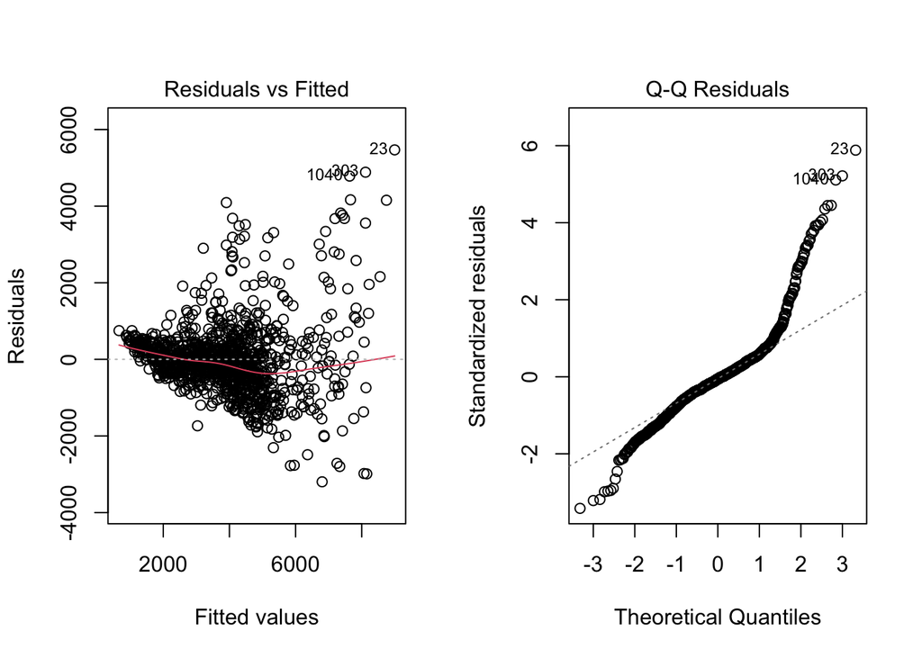

### Log-Salary Model with Robust Standard Errors

The log-salary regression was re-estimated using heteroskedasticity-robust standard errors to account for potential non-constant variance in the error terms. Out of all predictors, yrdeg (year highest degree attained) was the only variable that was no longer statistically significant, while all other coefficients, including the gender coefficient, remained statistically significant. The log of salary for women is 0.0498 lower than for men, controlling for other variables. After exponentiating, women earn about 4.85% lower starting salaries than men. Overall, our Question 1 analysis suggests that women receive lower starting salaries than men at the university. This difference persists even after controlling for rank, academic field, and experience-related factors in the regression models.

```
##
## t test of coefficients:
##
##               Estimate Std. Error t value  Pr(>|t|)
## (Intercept)  3.1455228  0.0845574 37.1999 < 2.2e-16 ***
## sexF        -0.0497548  0.0119122 -4.1768 3.191e-05 ***
## rankAssoc    0.2286783  0.0182214 12.5500 < 2.2e-16 ***
## rankFull     0.5877590  0.0264936 22.1849 < 2.2e-16 ***
## fieldOther   0.1070116  0.0108100  9.8993 < 2.2e-16 ***
## fieldProf    0.2283944  0.0165024 13.8401 < 2.2e-16 ***
## yrdeg       -0.0022370  0.0013591 -1.6459    0.1001
## startyr      0.0576450  0.0015716 36.6798 < 2.2e-16 ***
## ---
## Signif. codes:  0 '***' 0.001 '**' 0.01 '*' 0.05 '.' 0.1 ' ' 1
```

```
##
## Approximate percent difference for women in starting salary:
```

```
## -4.85 %
```

# 5. Q2: Wage Discrimination in Promotion

In addition to starting salaries, promotion dynamics can contribute to long-term salary disparities. Academic promotion, particularly advancement from Associate Professor to Full Professor, often leads to substantial salary increases. We now investigate for gender differences in wage increases that occur at promotion. We constructed a promotion-level dataset containing one observation per faculty member at the first observed Associate-to-Full transition. For each promoted faculty member, we computed both the dollar rise and the percent raise This yielded 547 promoted faculty members, including 447 men and 100 women.

### Salary Increase at Promotion by Sex

Women had slightly larger promotion raises on average than men. The mean dollar rise was about $516.69 for women and $469.98 for men, while the mean percent raise was 12.9% for women and 12.4% for men.

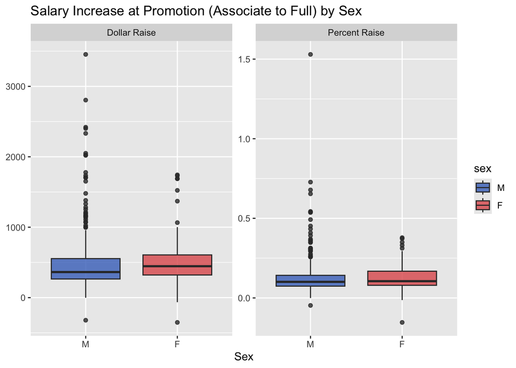

### Statistical Tests

For the Welch two-sample t-tests, we test $H_0: \mu_M - \mu_F = 0$ versus $H_A: \mu_M - \mu_F \neq 0$,  
where $\mu_M$ and $\mu_F$ represent the population mean promotion raises for men and women, respectively.

For the Wilcoxon rank-sum test, the null hypothesis states that the distributions of percent raises for men and women are identical, while the alternative hypothesis states that the distributions differ.

We first conducted statistical tests comparing promotion raises between men and women without controlling for other factors. Welch two-sample t-tests were used to compare both the dollar raise and the percent raise at promotion. Although women had slightly larger average raises than men in both measures, neither difference was statistically significant. Because raise distributions may be skewed, we also performed a Wilcoxon rank-sum test for percent raise as a nonparametric check, which similarly found no significant difference between men and women. We do not have sufficient statistical evidence to reject the null hypothesis.

| Test | Measure | Mean (M) | Mean (F) | Test Statistic | p-value | 95% CI |
| --- | --- | --- | --- | --- | --- | --- |
| Welch t-test | Dollar raise ($) | 469.98 | 516.69 | t = -1.1385 | 0.2566 | [-127.74, 34.33] |
| Welch t-test | Percent raise | 12.43% | 12.90% | t = -0.4517 | 0.6520 | [-2.51%, 1.57%] |
| Wilcoxon | Percent raise | — | — | W = 20318 | 0.1550 | — |

### Regression Models

We estimated linear regression models for both the dollar raise and the percent raise received at promotion from Associate Professor to Full Professor. The models included gender, academic field, year of highest degree, and pre-promotion salary (prev_salary) as predictors. Including prev_salary controls for the baseline salary level prior to promotion, since raise amounts and percentage increases often depend on the starting salary. Model equations:

$$\text{raiseamount}_i =
\beta_0 + \beta_1\,sexF_i
+ \beta_2\,I(field_i=\text{Other})
+ \beta_3\,I(field_i=\text{Prof})
+ \beta_4\,yrdeg_i
+ \beta_5\,prev\_salary_i
+ \epsilon_i$$

$$\text{raisepct}_i =
\beta_0 + \beta_1\,sexF_i
+ \beta_2\,I(field_i=\text{Other})
+ \beta_3\,I(field_i=\text{Prof})
+ \beta_4\,yrdeg_i
+ \beta_5\,prev\_salary_i
+ \epsilon_i$$

In the dollar raise model, the coefficient on the female indicator was small and not statistically significant, indicating no evidence that women received smaller raises than men at the time of promotion after controlling for field, experience, and prior salary. Using heteroskedasticity-robust standard errors did not change these conclusions. In the percent raise model, the gender coefficient likewise remained small and statistically insignificant.

| Metric | $ Raise (Std. SE) | $ Raise (Robust SE) | % Raise (Std. SE) | % Raise (Robust SE) |
| --- | --- | --- | --- | --- |
| sexF coef estimate | 25.86 | 25.86 | 0.0023 | 0.0023 |
| sexF p-value | 0.546 | 0.522 | 0.849 | 0.822 |
| R-squared | 0.074 | 0.074 | 0.079 | 0.079 |
| Adj. R-squared | 0.066 | 0.066 | 0.071 | 0.071 |

Our regression results show no statistically significant difference in promotion raises between men and women after controlling for field, year of highest degree, and pre-promotion salary. This finding is consistent across both dollar and percent raise models and remains unchanged when using heteroskedasticity-robust standard errors. Prior to conducting this analysis, we expected that gender disparities might also appear in promotion raises. However, the results suggest that the size of the raise at promotion itself does not differ systematically by gender once relevant factors are taken into account.

### Extension: Promotion Rates and Within-Rank Wage Gaps

While the main Q2 analysis examines salary increases at promotion, it is also useful to explore whether gender disparities arise through promotion rates or salary differences within academic ranks. This extension therefore examines:

1. Whether men and women are promoted from Associate Professor to Full Professor at different rates.
2. Whether salary differences exist within ranks after controlling for relevant characteristics.

#### Promotion Rates by Sex

We construct a person-level dataset of faculty who have ever held the rank of Associate Professor. For each individual, we record whether they were eventually promoted to Full Professor during the observation period.

We find that 59.9% of male Associate Professors were promoted to Full Professor, compared to 42.0% of female Associate Professors. While 447 of 746 men were promoted, only 100 of 238 women were promoted.

To test whether promotion rates differ significantly between men and women, we conducted a two-sample test for the difference in promotion proportions. We also performed a chi-square test of independence on the corresponding 2x2 contingency table. The two approaches are mathematically equivalent for a binary outcome, and both tests produced the same conclusion that the promotion rate differs significantly between men and women. Both tests produced consistent results, with a two-sample proportion test statistic of (z = -4.84) and an equivalent chi-square statistic of ($\chi^2$ = 23.43) (df = 1). These results provide evidence that women were significantly less likely to be promoted from Associate to Full Professor during the sample period.

#### Within-Rank Wage Gap Analysis

Next, we examine whether salary differences exist within academic ranks. For each rank (Associate and Full Professor), we estimate a log-linear regression model: $\log(\text{salary}_{it}) = \beta_0 + \beta_1\,sexF_i + \beta_2\,yrdeg_i + \beta_3\,year_t + \beta_4\,admin_{it} + \beta_5\,years\_exp_{it} + \beta_6\,I(field_i=\text{Other}) \\ + \beta_7\,I(field_i=\text{Prof}) + \beta_8\,I(deg_i=\text{PhD}) + \beta_9\,I(deg_i=\text{Prof}) + \epsilon_{it}$

The model controls for sex, year of degree, observation year, administrative role, years of experience, academic field, and degree type. Using log salary allows the coefficient on the gender indicator to be interpreted approximately as a percentage difference in salary.

The regression results show a statistically significant negative coefficient on the female indicator in both ranks. After controlling for experience, year effects, field, degree type, and administrative roles, women earn about 5–6% less than men on average among both Associate and Full Professors.

In contrast to the main Question 2 analysis, which found no gender difference in the size of wage increases at promotion, these results indicate that women were less likely to be promoted and earned modestly lower salaries than men within both ranks after controlling for observable characteristics. Together, these patterns suggest that gender disparities arise through promotion dynamics and within-rank wage differences, rather than differences in the raise received at promotion.

# 6. Q3: Overall Salary Discrimination

Collectively, we examine whether gender disparities exist in overall faculty salaries at the university. Because the dataset contains multiple observations for each faculty member over time, a full analysis of salary trajectories would normally require longitudinal methods. However, implementing a panel or longitudinal model is beyond the scope of this course. Instead, we construct a cross-sectional dataset by selecting the most recent salary observation for each faculty member, resulting in one row per individual representing their latest observed salary.

### Regression Model

To assess whether gender differences in salary persist after controlling for observable characteristics, we estimate three regression specifications using the latest salary for each faculty member:

1. Baseline salary model controlling for gender, rank, field, experience, and administrative role:

$salary_i = \beta_0 + \beta_1\,sexF_i + \beta_2\,I(rank_i=\text{Assoc}) + \beta_3\,I(rank_i=\text{Full}) + \beta_4\,I(field_i=\text{Other}) + \beta_5\,I(field_i=\text{Prof}) + \\ \beta_6\,experience_i + \beta_7\,admin_i + \epsilon_i$

2. Log-salary model, which accounts for the right-skewed distribution of salaries and allows coefficients to be interpreted approximately as percentage differences:

$\log(\text{salary}_i) = \beta_0 + \beta_1\,sexF_i + \beta_2\,I(rank_i=\text{Assoc}) + \beta_3\,I(rank_i=\text{Full}) + \beta_4\,I(field_i=\text{Other}) + \beta_5\,I(field_i=\text{Prof}) + \\ \beta_6\,experience_i + \beta_7\,admin_i + \epsilon_i$

3. Log-salary interaction model, which allows the gender salary gap to vary for faculty holding administrative positions:

$\log(\text{salary}_i) = \beta_0 + \beta_1\,sexF_i + \beta_2\,admin_i + \beta_3(sexF_i \times admin_i) + \beta_4\,I(rank_i=\text{Assoc}) + \beta_5\,I(rank_i=\text{Full}) + \\ \beta_6\,I(field_i=\text{Other}) + \beta_7\,I(field_i=\text{Prof}) + \beta_8\,experience_i + \epsilon_i$

For all models, we report results using both standard and heteroskedasticity-robust standard errors.

| Model | Coefficient | Estimate | Robust SE | p-value | Meaning (On Average) |
| --- | --- | --- | --- | --- | --- |
| **Baseline** | sexF | -409.32 | 70.02 | 6.10e-09 | Women earn about **$409 less** than comparable men |
| **Log-Salary** | sexF | -0.0590 | 0.0108 | 5.21e-08 | Women earn about **5.7% less** than comparable men |
| **Log-Salary Interaction** | sexF | -0.0492 | 0.0113 | 1.45e-05 | Among **non-administrators**, women earn about **4.8% less** than comparable men |
|  | sexF x admin | -0.1078 | 0.0322 | 0.000824 | Female administrators earn an additional **~10.8% less** than comparable male administrators |

In the baseline linear salary model, the coefficient on the female indicator is -409 and statistically significant. This suggests that, after controlling for rank, field, experience, and administrative roles, women earn about $409 less on average than comparable men. The result remains statistically significant when using heteroskedasticity-robust standard errors.

The log-salary model confirms the presence of a gender salary gap while accounting for the right-skewed distribution of salaries. The estimated coefficient on sexF is -0.059, which corresponds to an approximate salary difference of -5.7%, indicating that women earn about 5-6% less than comparable male faculty members.

Finally, the log-salary interaction model allows the gender salary gap to differ for faculty holding administrative roles. In this specification, the coefficient on sexF represents the gender difference among non-administrators, indicating that women in non-administrative positions earn about 4.8% less than comparable men. The interaction term sexF x admin is -0.108 and statistically significant, implying that female administrators earn an additional 10.8% less than comparable male administrators. Taken together, these results suggest that gender differences in salary persist overall and may be particularly pronounced among faculty holding administrative roles.

# 7. Q4: Issues in Generalizing Results

### Statistical Model Limitations

Several limitations arise from the statistical models used in this analysis. First, the regression specifications assume linear relationships between predictors and salary (or log-salary), which may not fully capture nonlinear salary growth over academic careers. Second, the models treat observations as independent even though the dataset contains repeated salary observations for the same individuals over time, potentially understating standard errors due to within-person correlation. Although heteroskedasticity-robust standard errors and log-salary models help improve inference, these adjustments address statistical issues rather than resolving underlying model limitations. Finally, because the analysis is based on observational data rather than experimental design, the results should be interpreted as associations rather than causal estimates of gender discrimination.

### Data and Scope Limitations

Additional limitations arise from the dataset and the scope of the study. The data represent a single university between 1976 and 1995, and compensation structures, promotion policies, and hiring practices vary across institutions and time periods. As a result, the patterns observed three decades ago may not generalize to other universities or to more recent academic labor markets. Furthermore, the dataset does not contain information on important determinants of academic compensation such as research productivity, publication records, grant funding, or teaching performance. These unobserved factors may influence salary outcomes and could partially explain some of the observed relationships. Finally, the analysis focuses on specific outcomes such as starting salaries and promotion raises while other dimensions of academic careers, including time to promotion or administrative opportunities, may also contribute to long-term disparities.

# Conclusion

### Comparison of Results

Our results from Parts 4, 5, and 6 suggest that gender disparities in faculty pay are present, but they do not arise in exactly the same way at every stage of an academic career. In Part 4, we found evidence of a gender gap in starting salaries: even after controlling for rank, field, degree year, and hire year, women earned lower starting salaries than comparable men, with the log-salary model indicating an estimated gap of about 4.85%.

Part 5 leads to a more nuanced conclusion. Our main promotion-raise analysis found no statistically significant gender difference in the size of the raise received at the Associate-to-Full promotion. On its own, this result might seem to weaken the case for gender-based wage discrimination. However, it does not contradict the conclusions from Parts 4 and 6, because it addresses a much narrower question: whether men and women who were promoted received different incremental raises at that specific transition. That is different from asking whether women faced disadvantages in initial salary setting, in the likelihood of being promoted, or in salaries within rank. In fact, the extension in Part 5 showed that women were less likely to be promoted from Associate to Full Professor and also earned about 5–6% less within rank among both Associate and Full Professors, even after controlling for observable characteristics. These findings suggest that gender disparities may operate through promotion access and within-rank pay differences, rather than through the size of the raise once promotion occurs.

Part 6 reinforces the broader conclusion that overall salary discrimination persists at the university. Using the most recent salary observation for each faculty member, we found that women earned about $409 less than comparable men in the linear model and about 5.7% less in the log-salary model. The interaction model further suggested that the gender gap may be even larger among administrators. Thus, even though the promotion-raise result in Part 5 did not show unequal raises at the moment of promotion, the overall evidence across the project still points to persistent gender disparities in salary outcomes.

Overall, the Part 5 finding is best understood as related but not contradictory to the overall conclusion. It tells us that the observed salary gap is not primarily driven by unequal raises at promotion itself. Instead, the combined evidence from Parts 4, 5, and 6 suggests that gender inequality is more likely to emerge through lower starting salaries, lower promotion rates, and lower salaries within rank, which then accumulate over time into the broader salary disparities observed in Part 6.

### Future Work

Several avenues for future research remain. One promising direction would be to model salary trajectories using panel data methods to examine how gender disparities evolve over time. Additional work could also study promotion timing using survival analysis to determine whether women experience longer paths to promotion. Expanding the analysis to multiple institutions and incorporating additional measures of faculty productivity, such as publications and grant funding, would further clarify the mechanisms underlying observed salary gaps.